# Breast Cancer Classification using Proteomic Data

May 8, 2022

## Contents

1. Introduction
2. Materials and Methods
   - Work chart
3. Results
   - K-means clustering after PCA of common proteins after GLM
   - K-means clustering after PCA of full BC data
   - K-means clustering after PCA of Protein IDs common between PAM50 data and BC data
4. Discussion

## Introduction

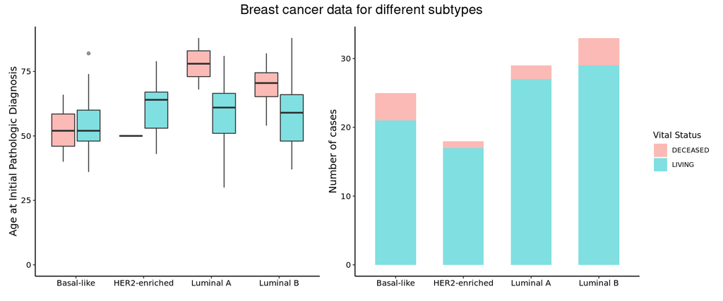

- Prevalence: 13% in women
- Mortality rate: 2.6%
- Symptoms: little to no before it is widespread
- 4 Tumor types: Vary in location, size, shape and severity

Cancer.org, “Key Statistics for Breast Cancer” (2022). https://www.cancer.org/cancer/breast-cancer/about/how-common-is-breast-cancer.html

## Aim

In this project we will investigate whether it is possible to detect and correctly classify the 4 breast cancer subtypes using different sets of protein expression data and compare the results of the classification.

## Materials and Methods

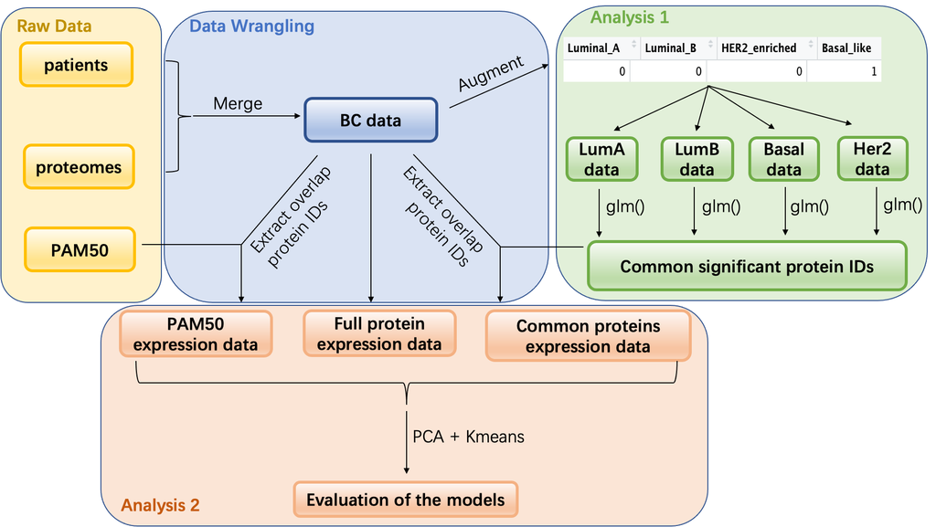

Mertins, P., Mani, D., Ruggles, K. et al. Proteogenomics connects somatic mutations to signalling in breast cancer. Nature 534, 55–62 (2016). https://doi.org/10.1038/nature18003

## Results - Common proteins after GLM

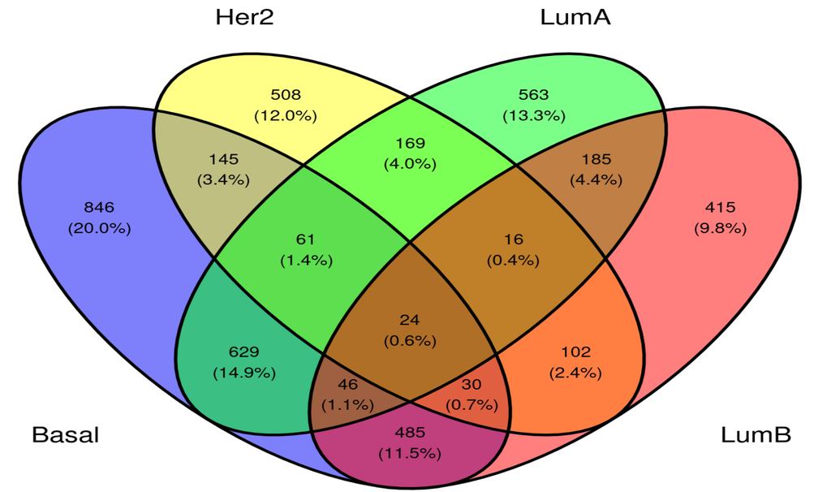

- Still found 1000 more significant proteins in each subtype after `glm()`
- `ggvenn()`
- Only 24 significant protein IDs common for all the 4 subtypes

## Results - Common proteins after GLM

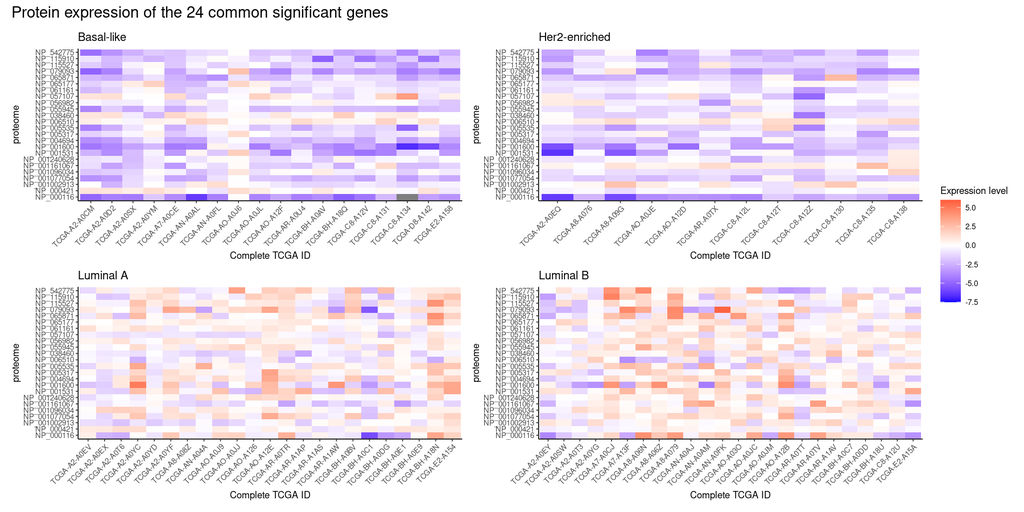

- Downregulated: Basal-like and HER2-enriched.
- Upregulated: Luminal-A and Luminal-B
- Similar protein expression levels between each patient within heat maps

## Results - Common Protein BC Data

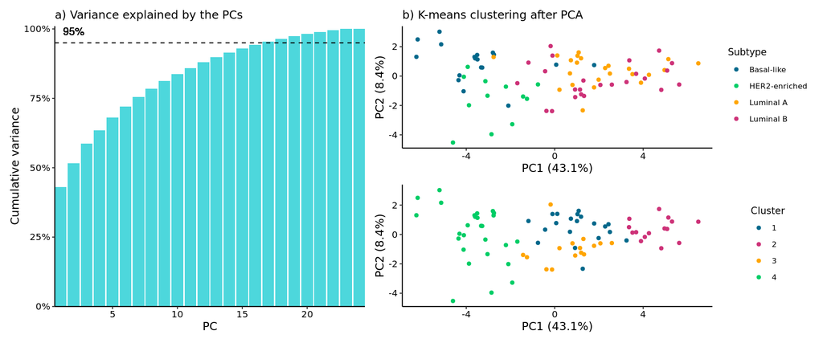

## Results - Full BC data

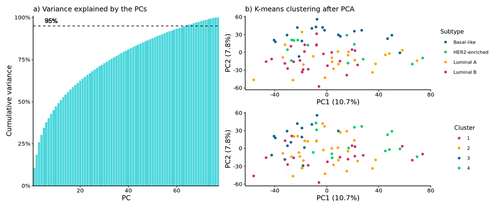

- Number of PCs reduced from 77 to 65
- No clear patterns
- Little of the variance is explained by PC1 and PC2
- Accuracy of plot: 36.4%

## Results - Protein IDs common between PAM50 data and BC data

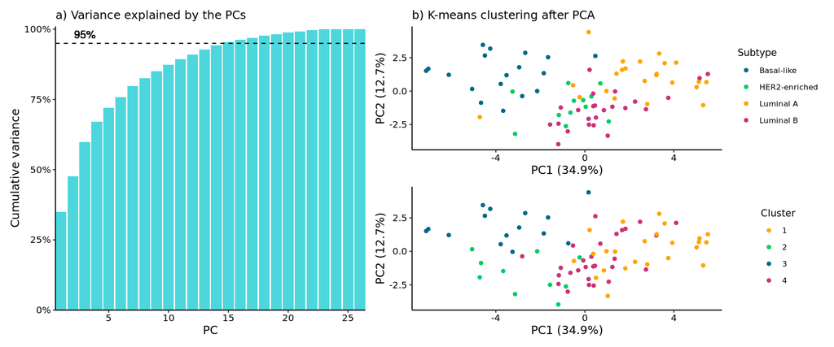

- Number of PCs reduced from 26 to 15
- 1st PC explains a much higher variance (34.9% compared to 10.7%)
- Accuracy of this exact plot: 48.1%

## Discussion

- Best performer: PAM50
  - Only 26 out of 100 protein IDs used
- Only considering the common genes instead of e.g. the unique genes
- Improvements
  - Cluster Luminal-A and Luminal-B together
- Reproducible method